# EDA on NYC Test Scores Data

# Analyzing Test Data on a School-level Granulatrity 2006-2015

```r
setwd('C:\\Users\\ransf\\Documents\\SchoolData')
df1 <- read.csv("SchoolELAResults20062012Public_ALL.csv")
df1 <- initial_reshape_school_data(df1, "ELA")
```

```r
setwd('C:\\Users\\ransf\\Documents\\SchoolData')
df2 <- read.csv("SchoolELAResults20062012Public_ELL.csv")
df2 <- initial_reshape_school_data(df2, "ELA")

setwd('C:\\Users\\ransf\\Documents\\SchoolData')
df3 <- read.csv("SchoolELAResults20062012Public_Gender.csv")
df3 <- initial_reshape_school_data(df3, "ELA")

setwd('C:\\Users\\ransf\\Documents\\SchoolData')
df4 <- read.csv("SchoolELAResults20062012Public_Ethnicity.csv")
df4 <- initial_reshape_school_data(df4, "ELA")

ela.2006.2012.data <- bind_rows(df1,df2)
ela.2006.2012.data <- bind_rows(ela.2006.2012.data,df3)
ela.2006.2012.data <- bind_rows(ela.2006.2012.data,df4)
```

```r
setwd('C:\\Users\\ransf\\Documents\\SchoolData')
df1 <- read.csv("SchoolMathResults20062012Public_ALL.csv")
df1 <- initial_reshape_school_data(df1, "Math")

setwd('C:\\Users\\ransf\\Documents\\SchoolData')
df2 <- read.csv("SchoolMathResults20062012Public_ELL.csv")
df2 <- initial_reshape_school_data(df2, "Math")

setwd('C:\\Users\\ransf\\Documents\\SchoolData')
df3 <- read.csv("SchoolMathResults20062012Public_Ethnicity.csv")
df3 <- initial_reshape_school_data(df3, "Math")

setwd('C:\\Users\\ransf\\Documents\\SchoolData')
df4 <- read.csv("SchoolMathResults20062012Public_Gender.csv")
df4 <- initial_reshape_school_data(df4, "Math")

math.2006.2012.data <- bind_rows(df1,df2)
math.2006.2012.data <- bind_rows(math.2006.2012.data, df3)
math.2006.2012.data <- bind_rows(math.2006.2012.data, df4)
school_data.2006.2012 <- bind_rows(ela.2006.2012.data,math.2006.2012.data)

school_data <- bind_rows(school_data,school_data.2006.2012)
school_data <- create_borough_vector(school_data)
```

After combining all the data from 2006-2015, we have over 630,000 observations. First we examine the Level1Percentage vs. Number.Tested with aesthetic coloring of the Boroughs.

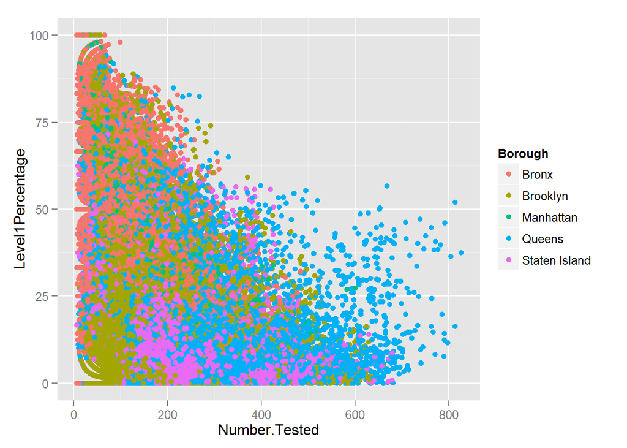

```r
ggplot(school_data, aes(x = Number.Tested, y = Level1Percentage)) + geom_point(aes(color = Borough))
```

Looking at the graph, I notice a large percentage of observations for Bronx and Brooklyn residing between 30 and 80 percent. These obersavations also seem to fall less than 200 students tested. Observations for Queens and Staten Island seem to fall below 25 percent when the number of students range from 100 to 500. It is tough to analyze observations for Manhattan in this plot. To get a better view, we will generate a plot with only observations for Manhattan

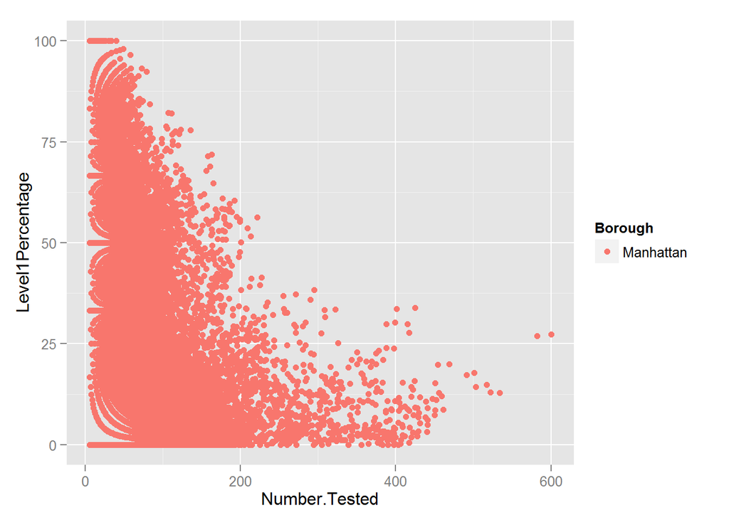

```r
ggplot(subset(school_data, Borough == "Manhattan" ), aes(x = Number.Tested, y = Level1Percentage)) + geom_point(aes(color = Borough))
```

The plot for Manhattan looks roughly the same as the original: high percentages of Level 1 students for those tested below 200 and lower percentages for those tested more than 200. Let’s do a facet wrap on the data based on Borough to see if this trend is across all boroughs.

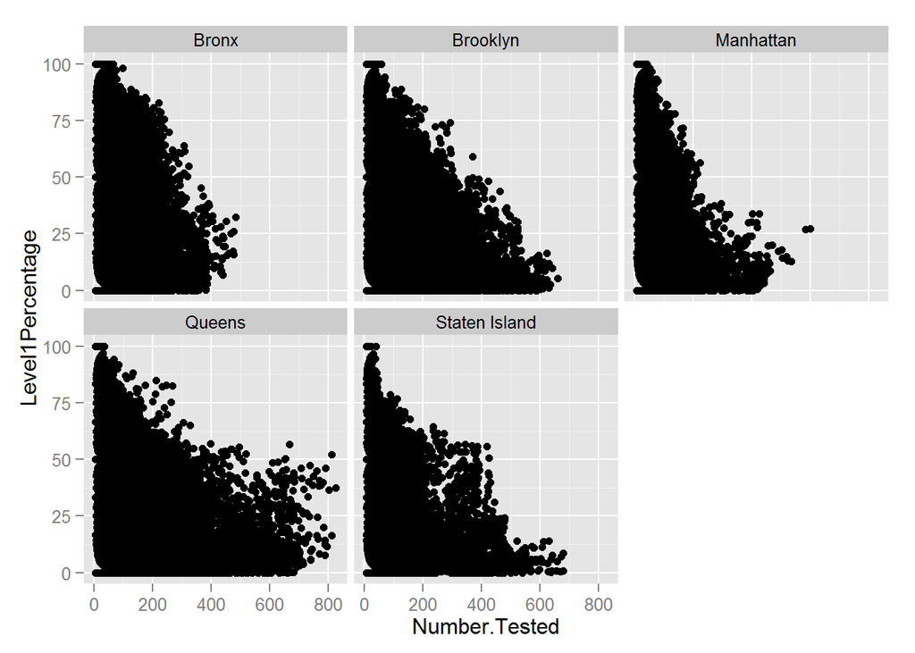

```r
ggplot(school_data, aes(x = Number.Tested, y = Level1Percentage)) + geom_point() + facet_wrap(~Borough)
```

It seems that across all boroughs, the percentage of Level 1 students decreases after the number of students tested passes a specific threshold. My suscipsion is that the number of Level 1 students remains constant, but since the population size of students tested increases, they become a smaller percentage. Let’s see if the data supports this hypothesis, but comparing the Level1Count vs Number.Tested faceted over Boroughs

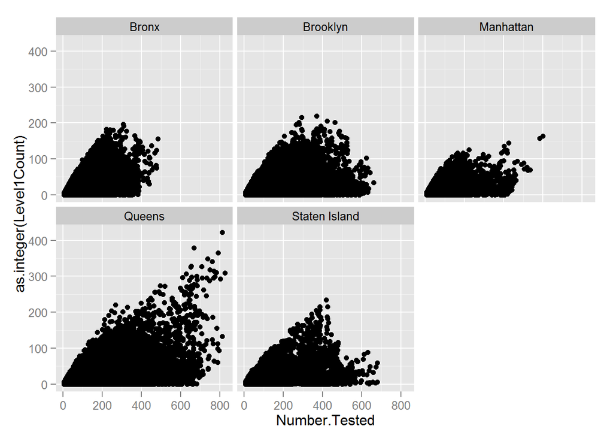

```r
ggplot(school_data, aes(x = Number.Tested, y = as.integer(Level1Count))) + geom_point() + facet_wrap(~Borough)
```

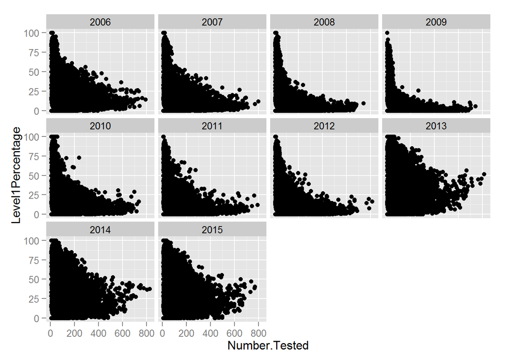

```r
ggplot(school_data, aes(x = Number.Tested, y = Level1Percentage)) + geom_point() + facet_wrap(~Year)
```

The trend seems to be the same from 2006-2012 with a consistent decrease in Level 1 students’ percentage from 2006-2009 for population sizes less than 200. From 2013 to 2015, there are larger percentages of Level 1 students across a wider range of student populations. This could be due to the change in NY Testing to be more Common Core aligned in 2013 as mentioned in the Notes of the dataset.

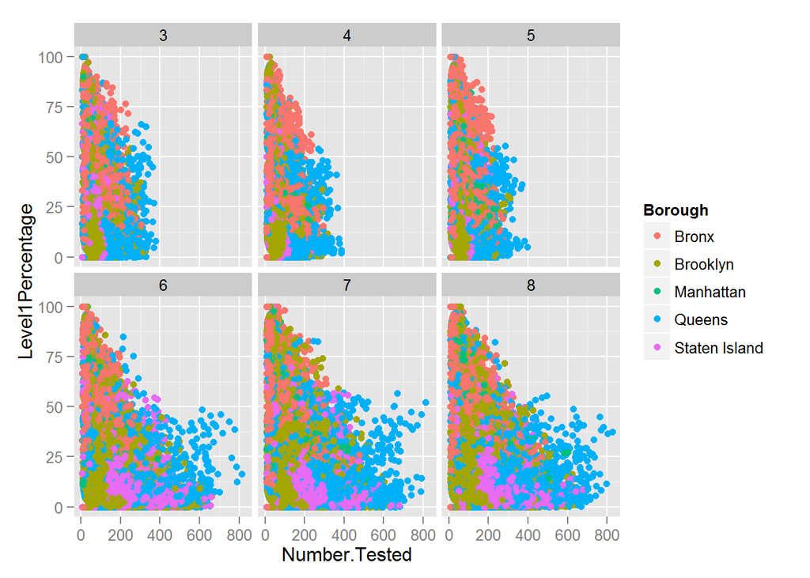

```r
ggplot(school_data, aes(x = Number.Tested, y = Level1Percentage)) + geom_point(aes(color=Borough)) + facet_wrap(~Grade)
```

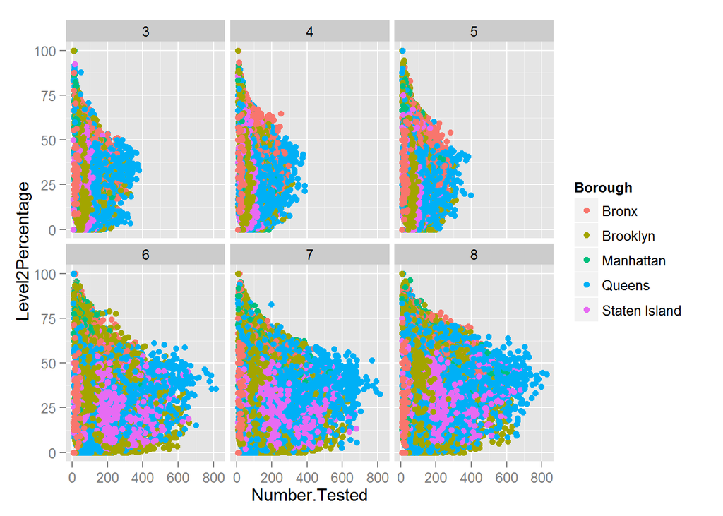

```r
ggplot(school_data, aes(x = Number.Tested, y = Level2Percentage)) + geom_point(aes(color=Borough)) + facet_wrap(~Grade)
```

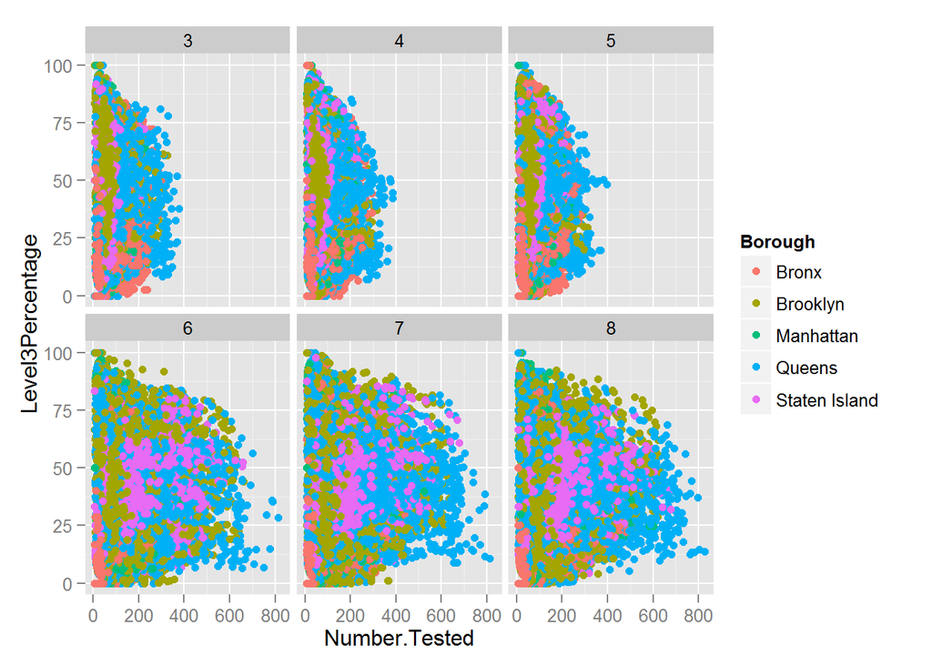

```r
ggplot(school_data,aes(x = Number.Tested, y = Level3Percentage)) + geom_point(aes(color=Borough)) + facet_wrap(~Grade)
```

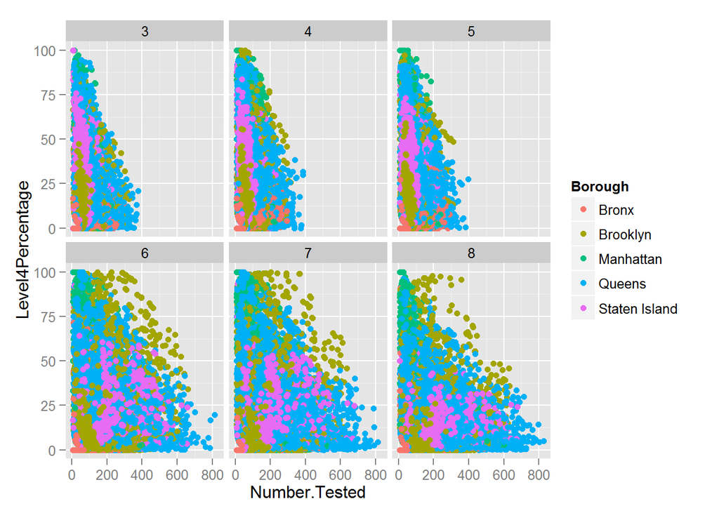

```r
ggplot(school_data,aes(x = Number.Tested, y = Level4Percentage)) + geom_point(aes(color=Borough)) + facet_wrap(~Grade)
```

The graphs tells us that the Bronx seems to have schools that struggle with standardized tests across all grades, Brooklyn may have struggling elementary schools, but has a good number of middle schools that perform well on standardized tests, Manhattan and Queens have schools that perform well in both elementary and middle and Staten Island has a lot of elementary schools that perform well, but their middle school performance varies.

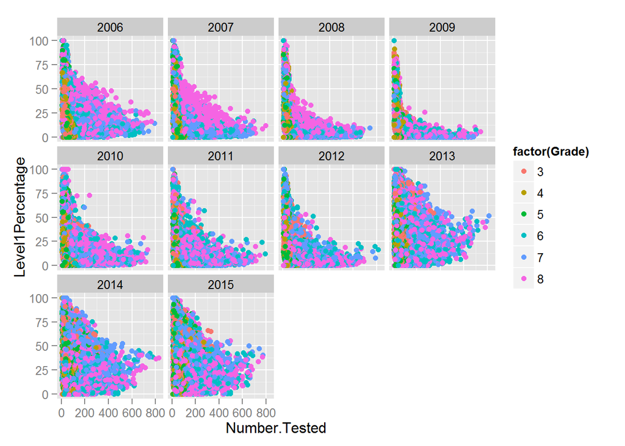

```r
ggplot(school_data, aes(x = Number.Tested, y = Level1Percentage)) + geom_point(aes(color=factor(Grade))) + facet_wrap(~Year)
```

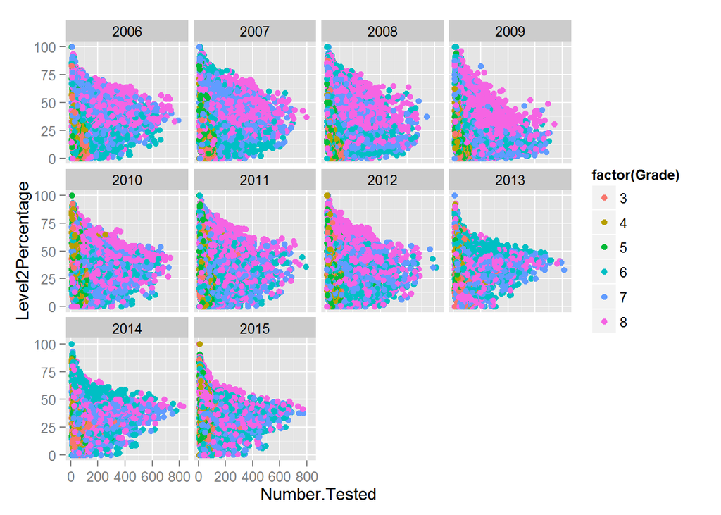

```r
ggplot(school_data,aes(x = Number.Tested, y = Level2Percentage)) + geom_point(aes(color=factor(Grade))) + facet_wrap(~Year)
```

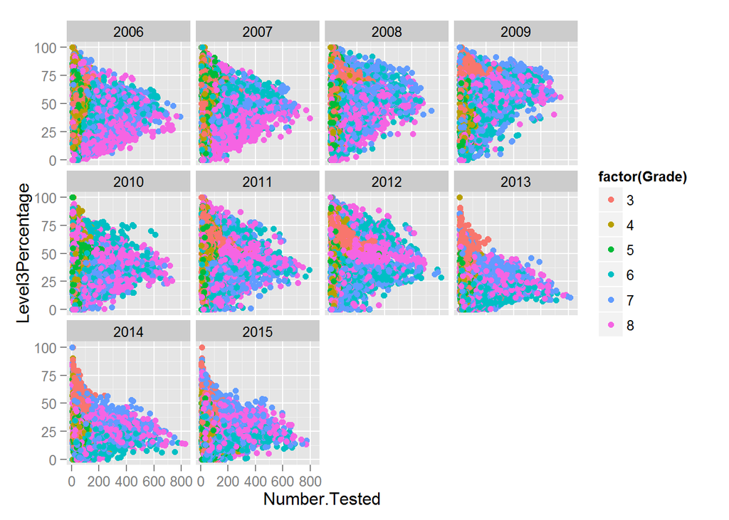

```r
ggplot(school_data, aes(x = Number.Tested, y = Level3Percentage)) + geom_point(aes(color=factor(Grade))) + facet_wrap(~Year)
```

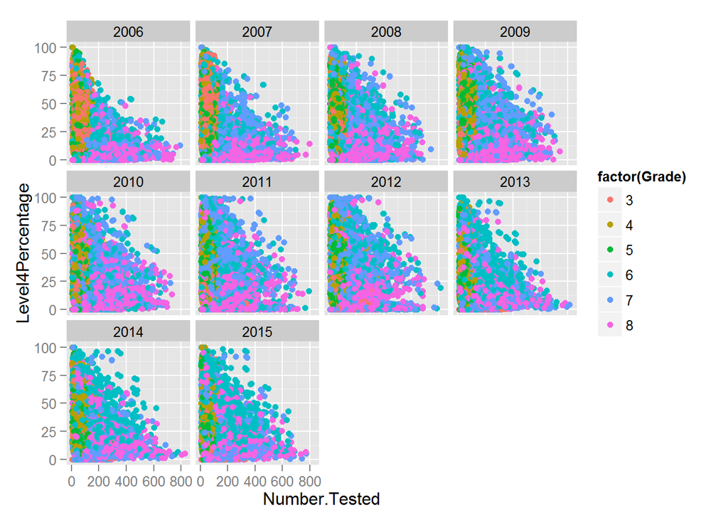

```r
ggplot(school_data, aes(x = Number.Tested, y = Level4Percentage)) + geom_point(aes(color=factor(Grade))) + facet_wrap(~Year)
```

2009 seems to be year for testing as their was high concentration of lower percentage of level 1 students, and a high concentration of higher percentage of level 3 students. We can see there was a big disruption in the distribution of test scores from 2013 when NYC decided to align more with the Common Core Standards. 8 graders seems to be having a difficult time with the standardized test as they dominate a large proportion in level 1 and 2 students. 6th and 7th graders seem to be doing the best over the years as they have large concentration of Level 3 and 4 students. 3rd and 6th graders seem to have weathered the change in Test standards in 2013. There is a dense concentration of Level 4 students in grades 3-5 from 2006-2009 but seems to dwindle after that.

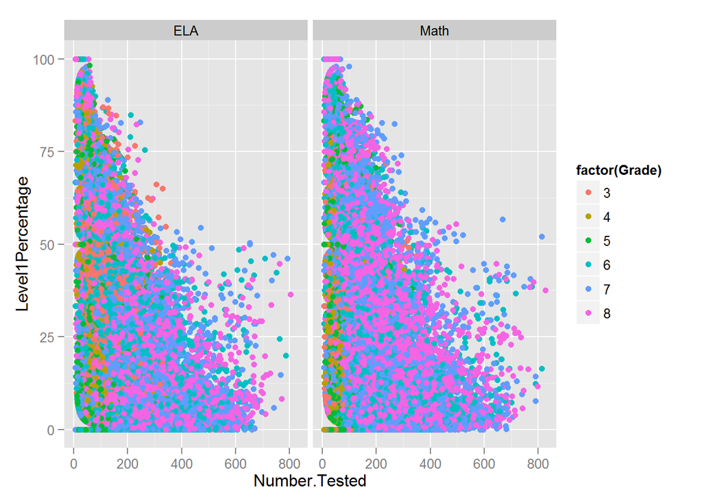

```r
ggplot(school_data, aes(x = Number.Tested, y = Level1Percentage)) + geom_point(aes(color=factor(Grade))) + facet_wrap(~Subject)
```

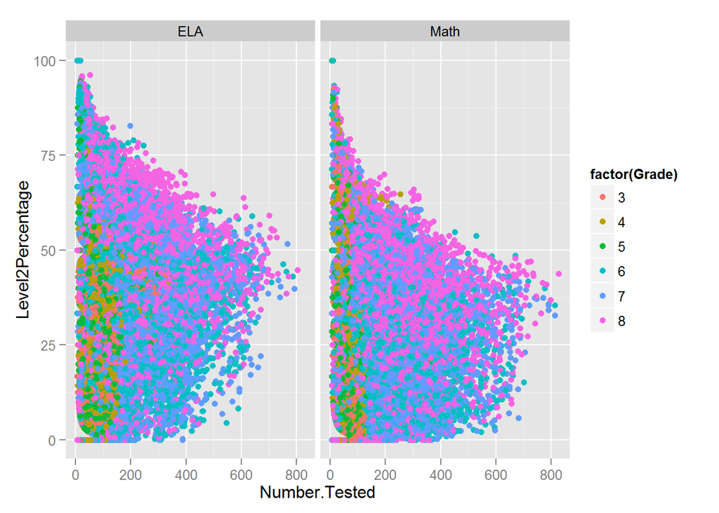

```r
ggplot(school_data, aes(x = Number.Tested, y = Level2Percentage)) + geom_point(aes(color=factor(Grade))) + facet_wrap(~Subject)
```

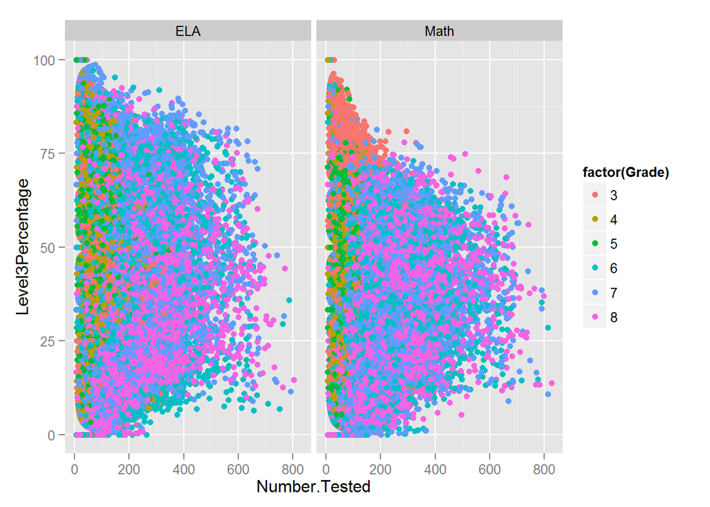

```r
ggplot(school_data, aes(x = Number.Tested, y = Level3Percentage)) + geom_point(aes(color=factor(Grade))) + facet_wrap(~Subject)
```

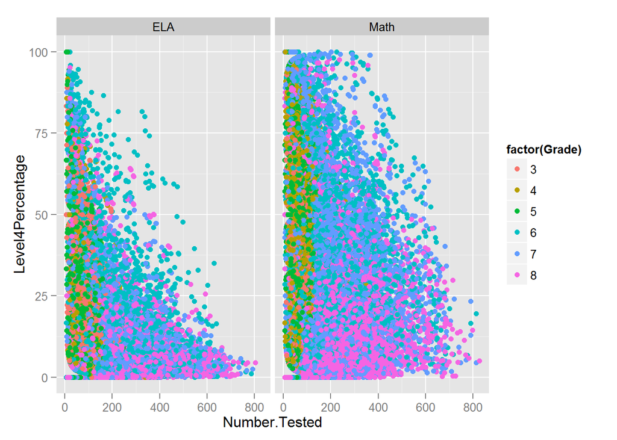

```r
ggplot(school_data, aes(x = Number.Tested, y = Level4Percentage)) + geom_point(aes(color=factor(Grade))) + facet_wrap(~Subject)
```

Performance seems to be good from grades 3-7, but falls drastically in 8th grade. Grades 4-6 seems to be the top performers in ELA. 8th grades seems to have large concentration of Level 1 and 2 students in both subjects.

```r
school_data_group <- school_data %>% group_by(DBN,Year,Grade) %>% summarise(Level1MeanPercent = mean(Level1Percentage), Level2MeanPercent = mean(Level2Percentage),Level3MeanPercent = mean(Level3Percentage),Level4MeanPercent = mean(Level4Percentage), n = n())

school_data_group <- create_borough_vector(school_data_group)
```

I have created another dataset which has the average percentages across all levels of students. Let’s analyze this dataset to see if it gives us any additional insight.

[output not shown]

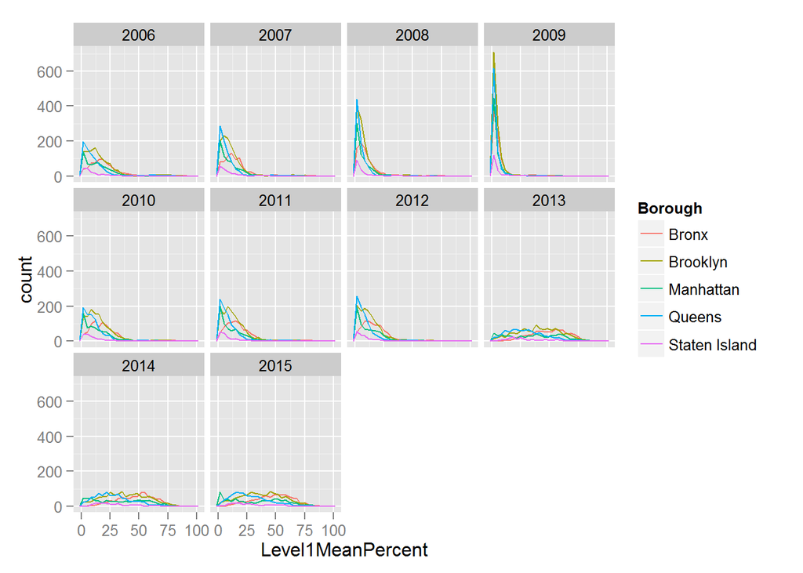

```r
ggplot(school_data_group, aes(x = Level1MeanPercent)) + geom_freqpoly(aes(color = Borough)) + facet_wrap(~Year)
```

[output not shown]

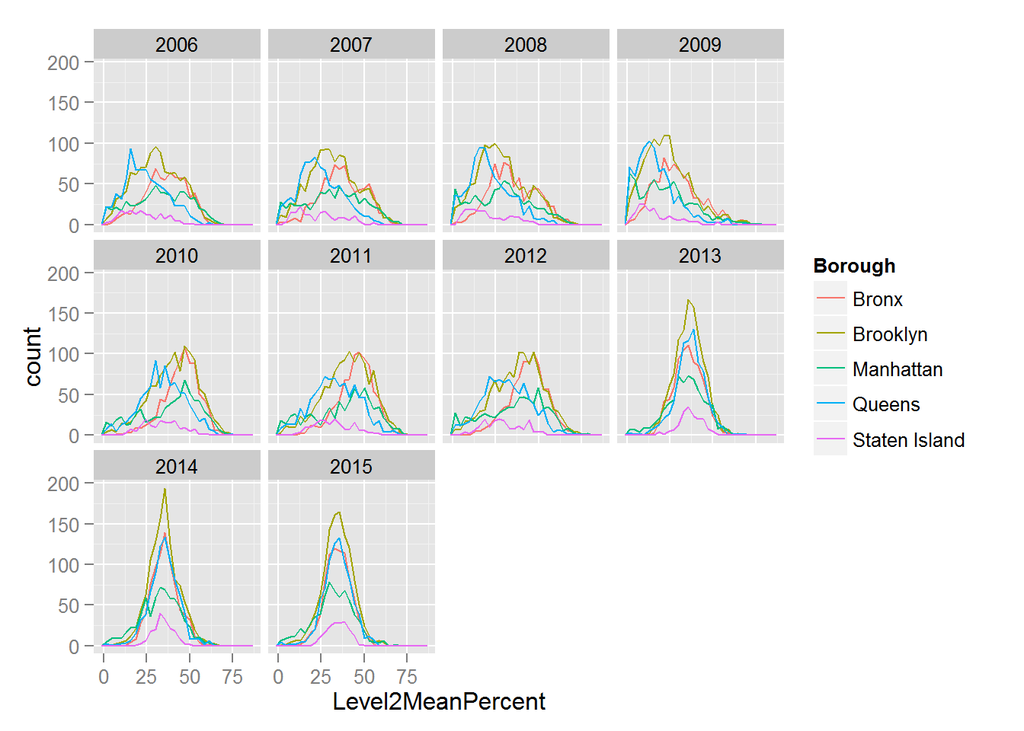

```r
ggplot(school_data_group, aes(x = Level2MeanPercent)) + geom_freqpoly(aes(color = Borough)) + facet_wrap(~Year)
```

[output not shown]

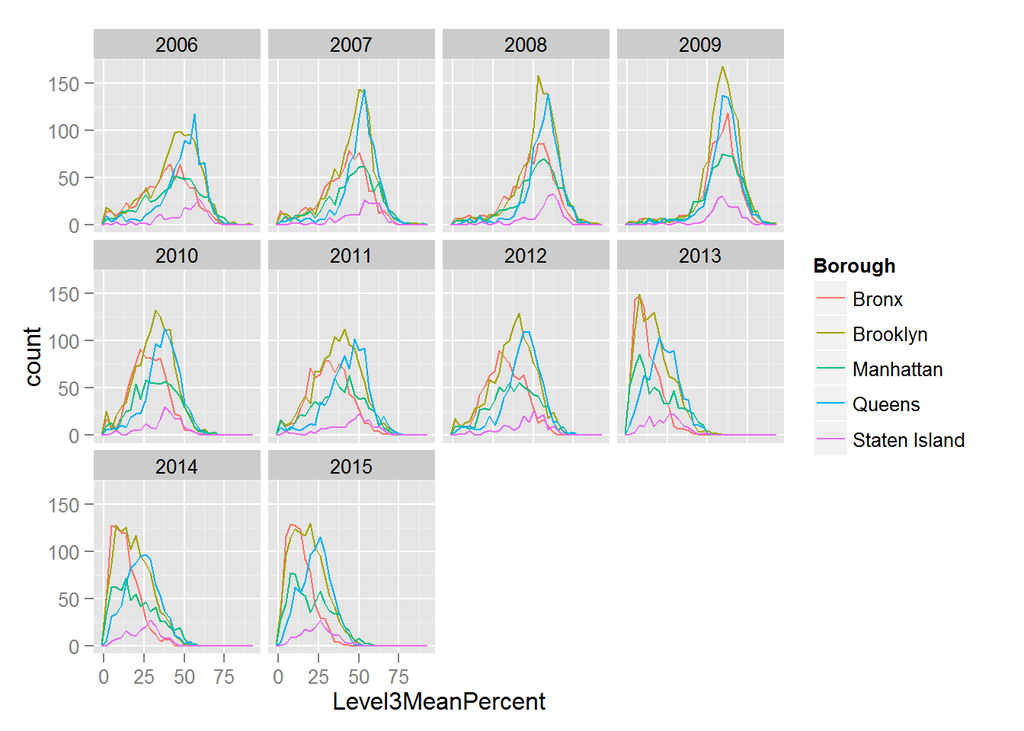

```r
ggplot(school_data_group, aes(x = Level3MeanPercent)) + geom_freqpoly(aes(color = Borough)) + facet_wrap(~Year)
```

[output not shown]

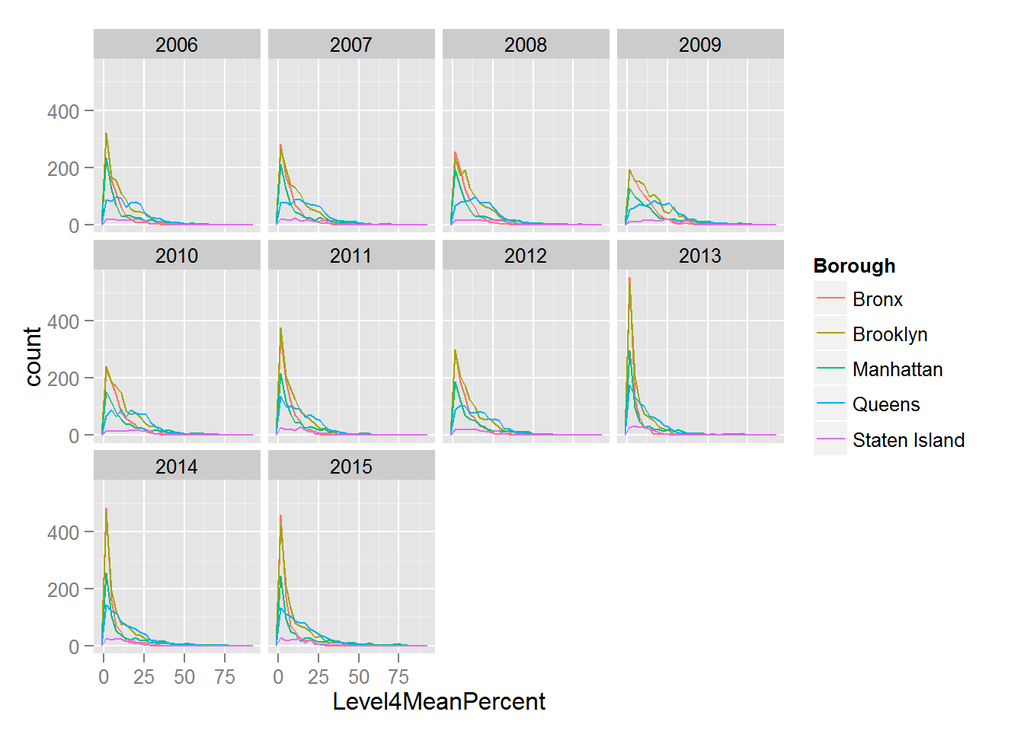

```r
ggplot(school_data_group, aes(x = Level4MeanPercent)) + geom_freqpoly(aes(color = Borough)) + facet_wrap(~Year)
```

The first I notice is how the Level 1 and 4 data is skewed and the Level 2 and 3 data is fairly normalized. The average percent of Level 1 students seems to be similarly distributed across all boroughs, but there is more distinction in the Level 2 data. Queens and Staten Island distributions’ mean are before 25 percent from 2006-2009, but align with boroughs’ distributions from 2010 onwards. The Bronx’s normal distribution slowly shifts right each year up until 2013, then the mean value shifts back left and stays there from 2013-2015. Manhattan’s mean oscillates left from 2006-2009 then to the right from 2010-2012 and stablizes from 2013-2015.

The average percentage of Level 4 students is below 25% for all boroughs across all years.

[output not shown]

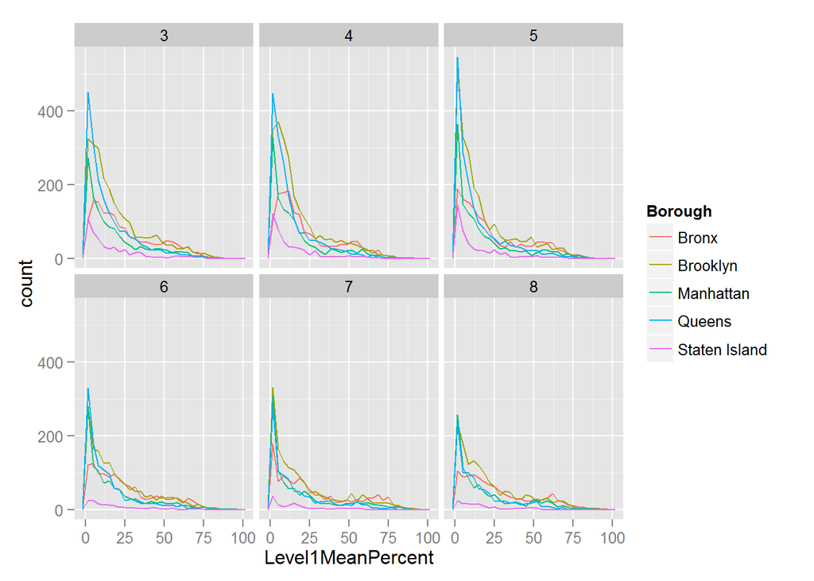

```r
ggplot(school_data_group, aes(x = Level1MeanPercent)) + geom_freqpoly(aes(color = Borough)) + facet_wrap(~Grade)
```

[output not shown]

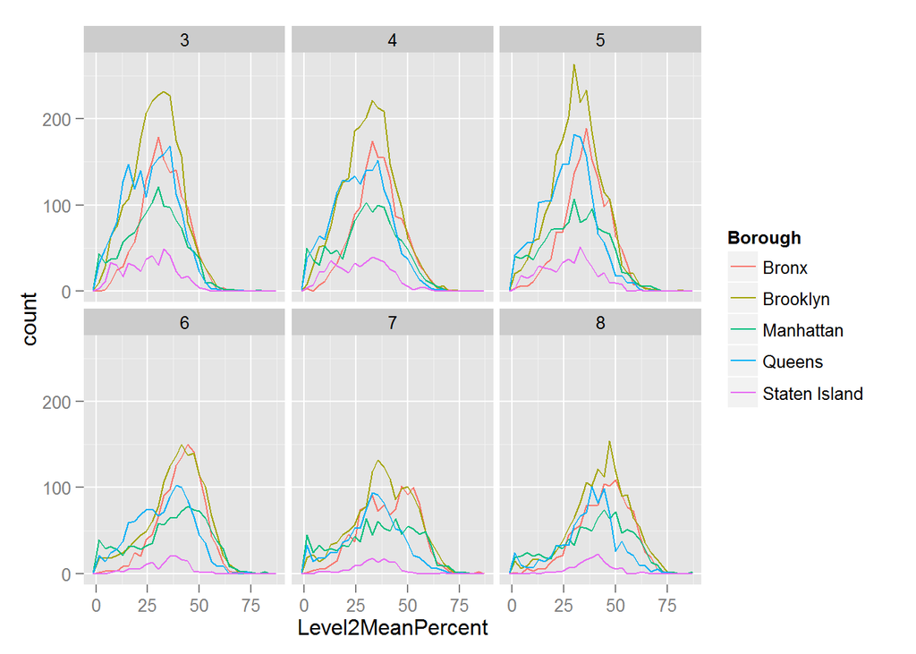

```r
ggplot(school_data_group, aes(x = Level2MeanPercent)) + geom_freqpoly(aes(color = Borough)) + facet_wrap(~Grade)
```

[output not shown]

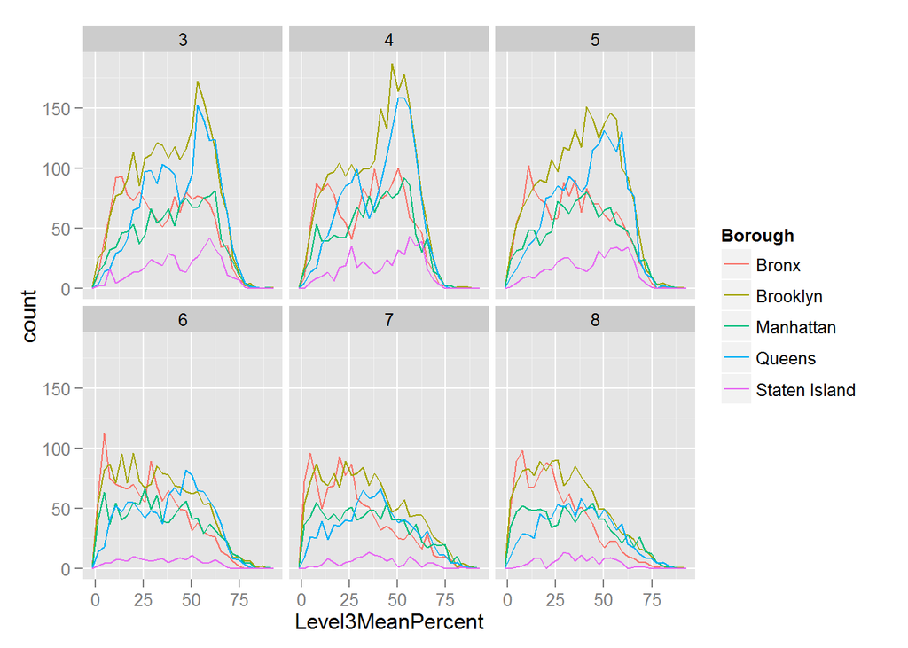

```r
ggplot(school_data_group, aes(x = Level3MeanPercent)) + geom_freqpoly(aes(color = Borough)) + facet_wrap(~Grade)
```

[output not shown]

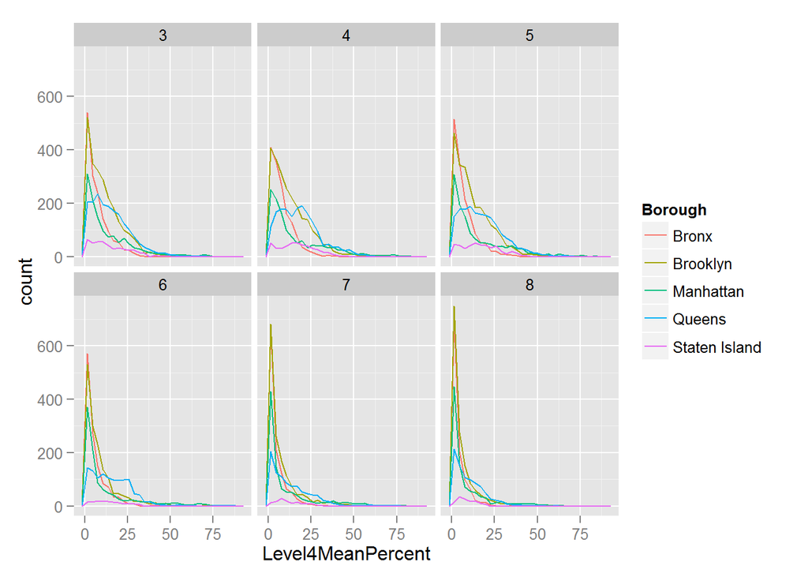

```r
ggplot(school_data_group, aes(x = Level4MeanPercent)) + geom_freqpoly(aes(color = Borough)) + facet_wrap(~Grade)
```

3-5th graders had a larger number of schools with low percentage averages for Level 1 students and Level 2 students (< 50%) and a high number of high percentage averages of Level 3 students. The number of Level 4 students with averages percentages greater than 25% are larger in 3rd-5th graders than 6-8th graders.

6-8th grade students have a large number of schools with average percentages around 50% for Level 2 students and average percentages around 20-35% for Level 3 students.

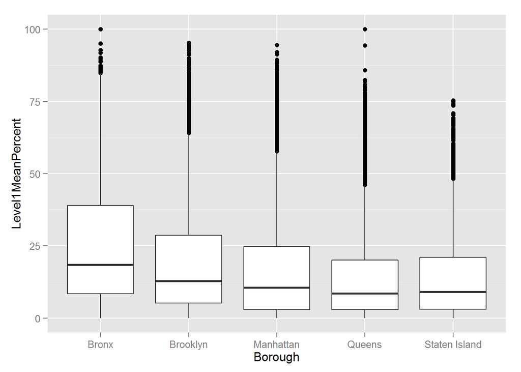

```r
ggplot(school_data_group, aes(y = Level1MeanPercent, x = Borough)) + geom_boxplot()
```

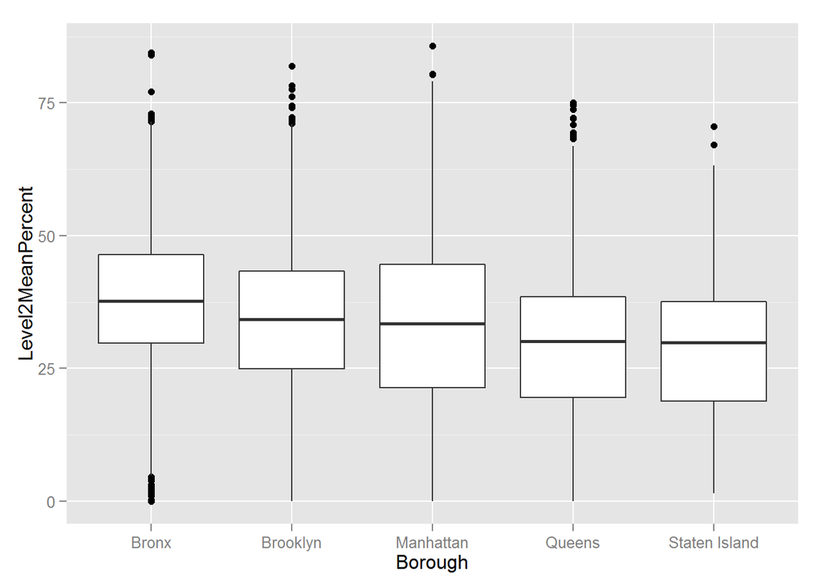

```r
ggplot(school_data_group, aes(y = Level2MeanPercent, x = Borough)) + geom_boxplot()
```

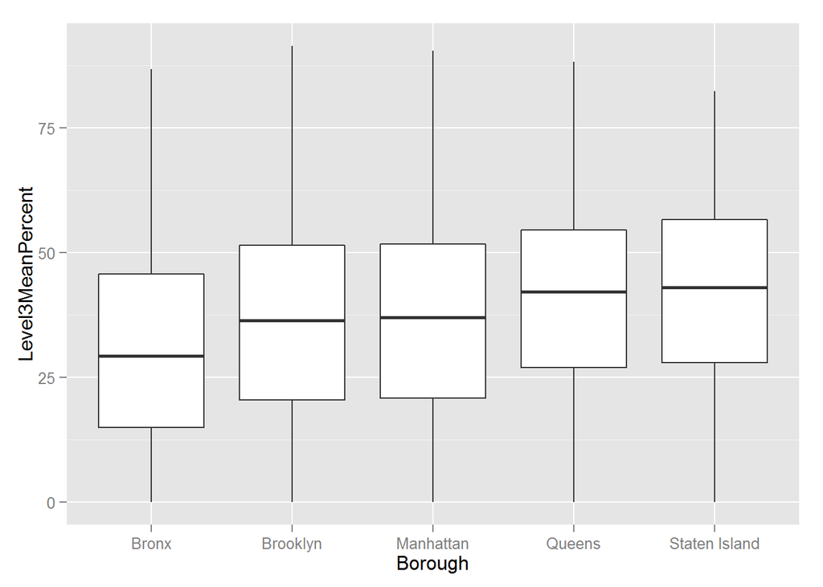

```r
ggplot(school_data_group, aes(y = Level3MeanPercent, x = Borough)) + geom_boxplot()
```

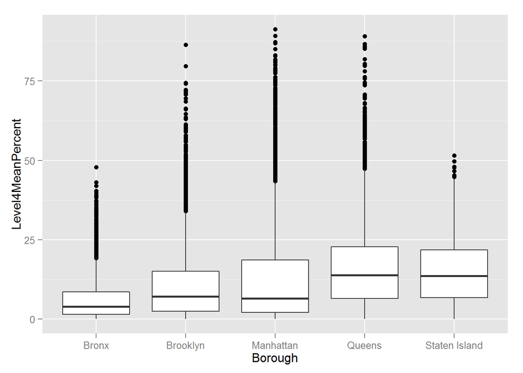

```r
ggplot(school_data_group, aes(y = Level4MeanPercent, x = Borough)) + geom_boxplot()
```

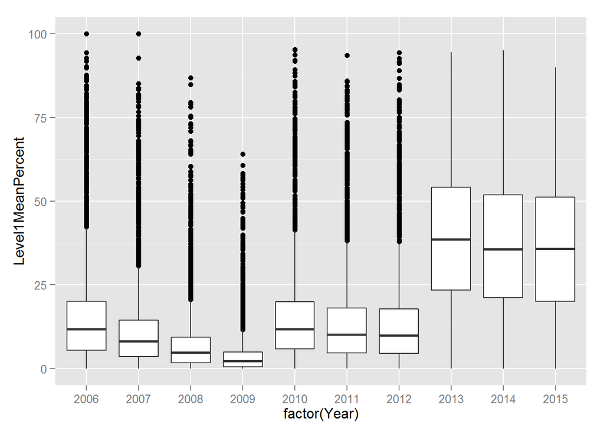

```r
ggplot(school_data_group, aes(y = Level1MeanPercent, x = factor(Year))) + geom_boxplot()
```

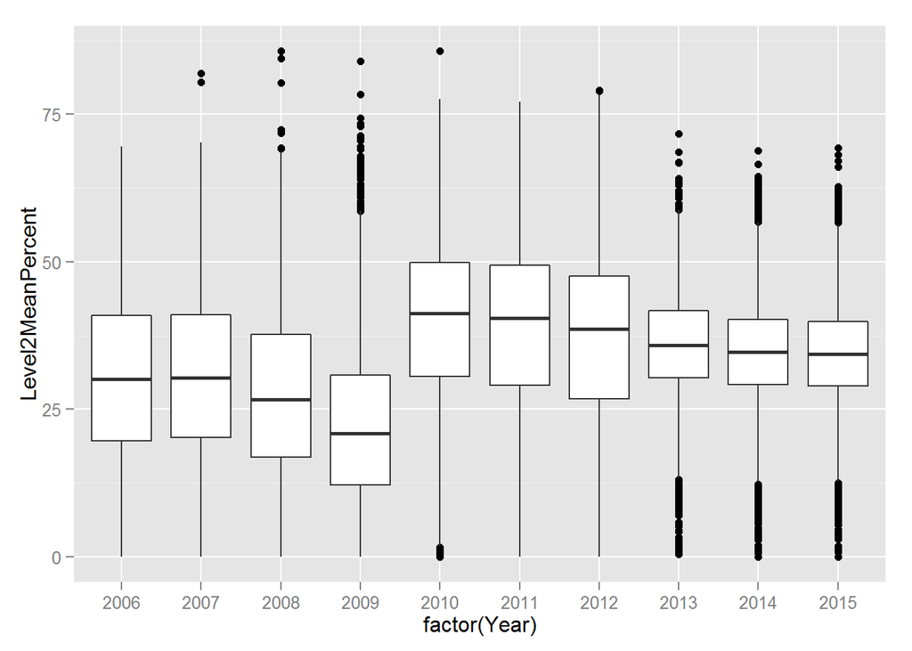

```r
ggplot(school_data_group, aes(y = Level2MeanPercent, x = factor(Year))) + geom_boxplot()
```

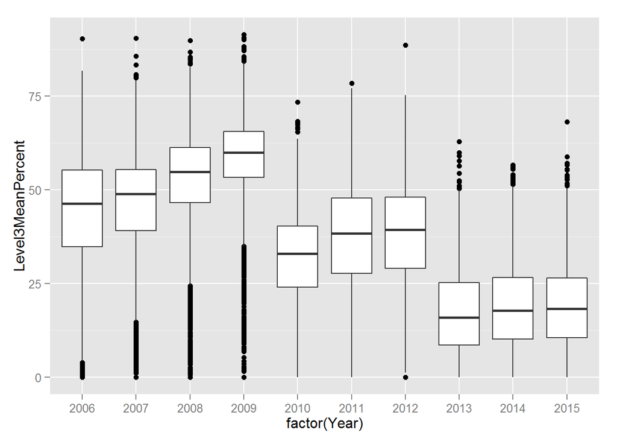

```r
ggplot(school_data_group, aes(y = Level3MeanPercent, x = factor(Year))) + geom_boxplot()
```

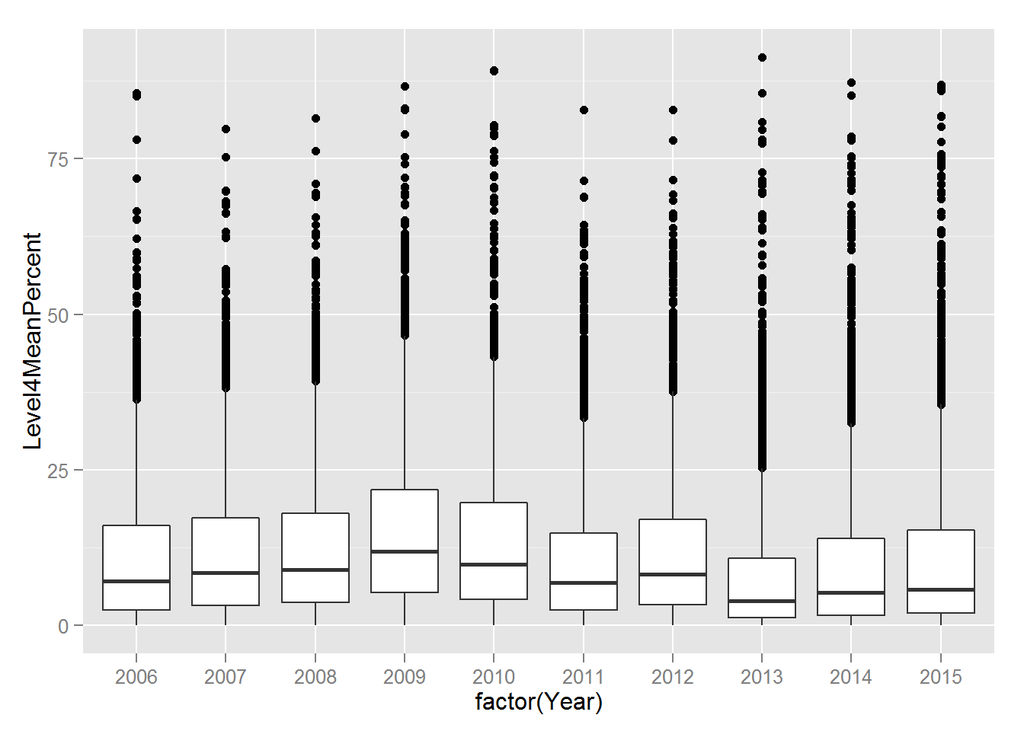

```r
ggplot(school_data_group, aes(y = Level4MeanPercent, x = factor(Year))) + geom_boxplot()
```

Plot support the claim that 2009 was the best year amongst them all showing lower median average percentages for Level 1 and 2 students and higher median average percentages for Level 3 and 4 students. Level 1 and 3 plots shows the most drastic changes across the years. In the Level 1 plot, the median values decrease over 2006-2009, then increased and remain constant from 2010-2012 and then increases sharply and remains constant from 2013-2015. The inverse trend is shown for Level 3 students.

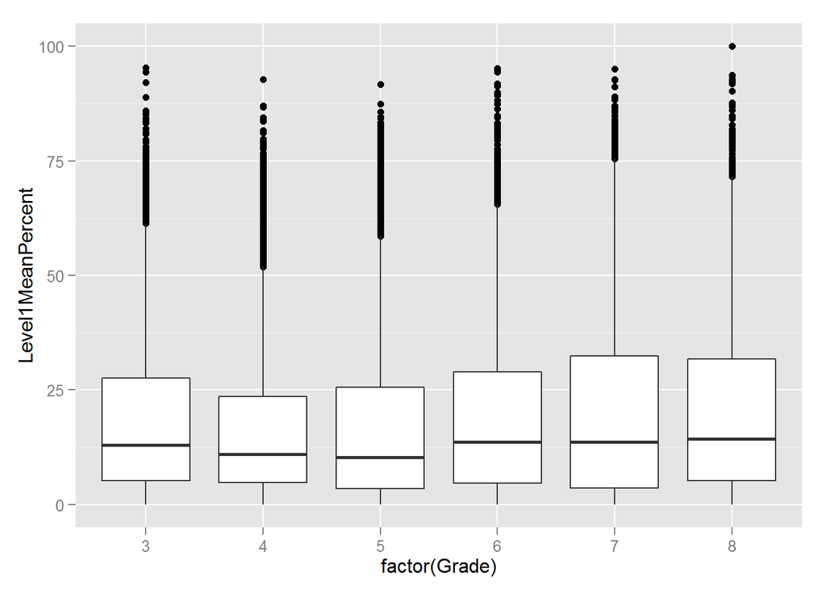

```r
ggplot(school_data_group, aes(y = Level1MeanPercent, x = factor(Grade))) + geom_boxplot()
```

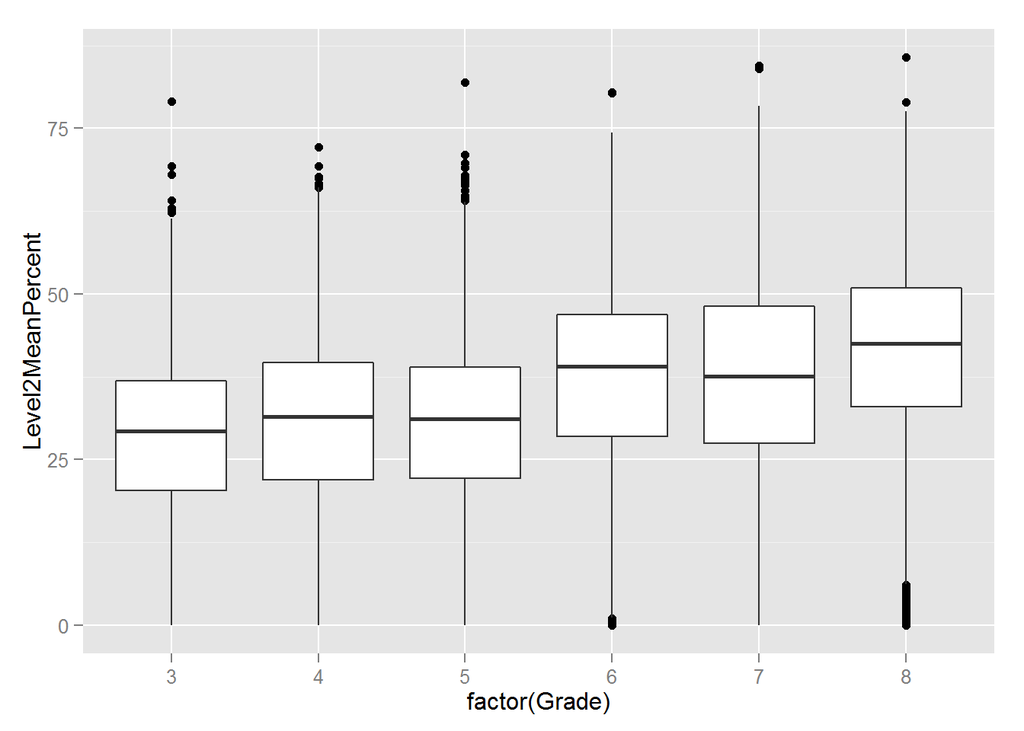

```r
ggplot(school_data_group, aes(y = Level2MeanPercent, x = factor(Grade))) + geom_boxplot()
```

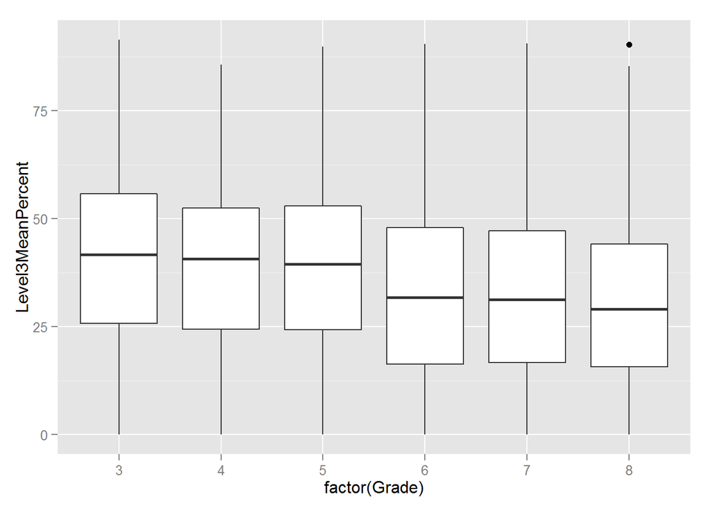

```r
ggplot(school_data_group, aes(y = Level3MeanPercent, x = factor(Grade))) + geom_boxplot()
```

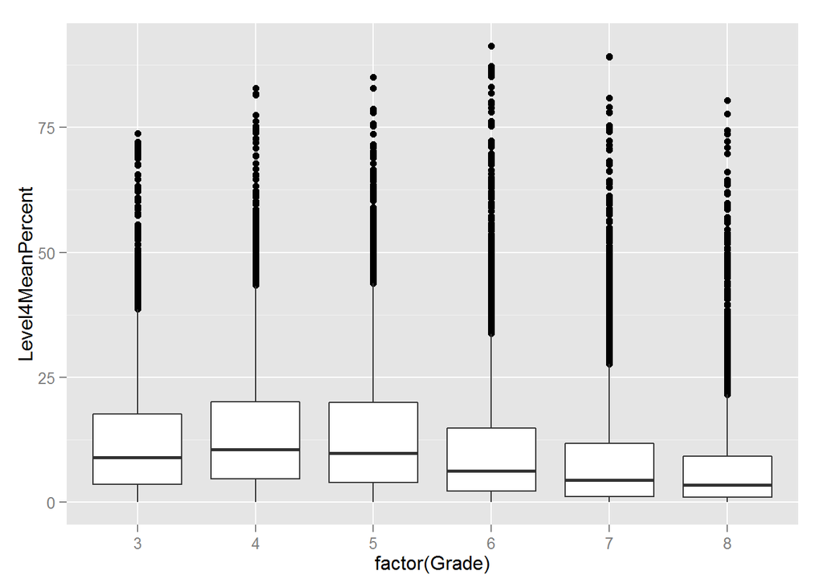

```r
ggplot(school_data_group, aes(y = Level4MeanPercent, x = factor(Grade))) + geom_boxplot()
```

The median value across grades is roughly equilvalent across all grades with a slight lower value for grades 3-5 for Level 1 and 2 students and slightly higher value for grades 3-5 for Level 3 and 4 students.